# Report

Author

Xiaojing Ni

### Data section

The data in this report is the Electricity Consumption and Occupancy (ECO) dataset (Beckel et al. (2014), Kleiminger, Beckel, and Santini (2015)). This dataset contains two parts: plug data and smart meter data. The plug data describes the energy consumption by second for each day by various appliances. The smart meter data is the energy consumption measured by three-phase smart meter for entire household. There are three households in the dataset: 04, 05, and 06. This report will show the household usage similarity and differences over a day, including the total usage and by different appliances. Thus, the households and their related total and average usage by hour from both plug data and smart meter data will be used in this report.

### Data-science questions

The main question is household usages similarity and differences over a day. This report is a demonstration to show how usage can be similar or different by households. If there are large scale household data, this will help to understand the overall usage pattern, so that utility provider can make plans for the adjustment when necessary, i.e. utility distribution during the peak hour.

More specific questions related to the individual visualizations are described as follow.

- How similar/difference is the average usage distributed by time for different households? For example, is there any peak time that usage from all households are high?
- How similar/difference is the average usage by appliances by different households throughout the day?

### Data preparation and EDA

#### EDA

This session performs Exploratory Data Analysis (EDA) with necessary data preparation.

##### Plug data

Load 04 household to explore.

```r
## read data

## plug 04 household
## Measurement period:
## 27.06.12 to 23.01.13

## 01: Fridge (no. days: 194, coverage: 97.01%)
## 02: Kitchen appliances (no. days: 194, coverage: 96.81%) (*)
## 03: Lamp (no. days: 170, coverage: 93.54%) (**)
## 04: Stereo and laptop (no. days: 169, coverage: 90.98%)
## 05: Freezer (no. days: 192, coverage: 93.08%)
## 06: Tablet (no. days: 189, coverage: 93.6%)
## 07: Entertainment (no. days: 186, coverage: 94.69%) (***)
## 08: Microwave (no. days: 194, coverage: 97.08%)

appliance <- c("01", "02", "03", "04", "05", "06", "07", "08")
for (a in appliance) {
  file_list <-
    list.files(
      path = paste0("../../eco/04_plug/", a),
      pattern = ".csv",
      all.files = FALSE,
      full.names = FALSE
    )

  ## initiate variable name for each applicance
  df_name <- paste0("p04_", a)

  for (file in file_list) {
    path <- paste0("../../eco/04_plug/", a, "/", file)

    # if the merged dataset doesn't exist, create it
    if (!exists(df_name)) {
      temp <- read.table(path, header = FALSE)
      colnames(temp) <- substr(file, 1, 10)
      assign(df_name, temp)
      rm(temp)
      next
    }

    # if the merged dataset does exist, append to it
    if (exists(df_name)) {
      temp_dataset <- read.table(path, header = FALSE)
      colnames(temp_dataset) <- substr(file, 1, 10)
      temp <- cbind(get(df_name), temp_dataset)
      assign(df_name, temp)
      rm(temp_dataset, temp)
    }
  }
}
```

The plug data for 04 household solely took 1G ram, ~1 mins to read. This indicate that the data is needed to be aggregated in some way to plot.

Plot 04 household Fridge data on 2012-06-27 as example. There is not much information from the plot.

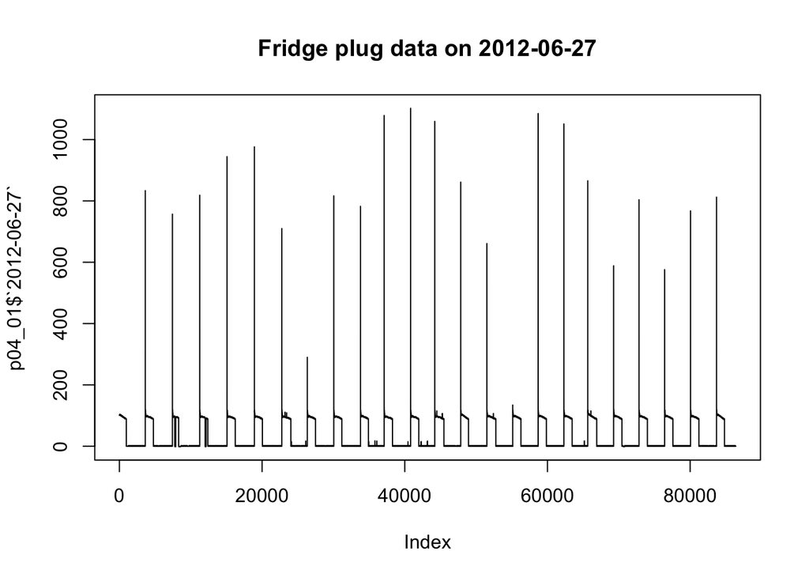

```r
# sample plot
plot(p04_01$`2012-06-27`, type = "l", main = "Fridge plug data on 2012-06-27")
```

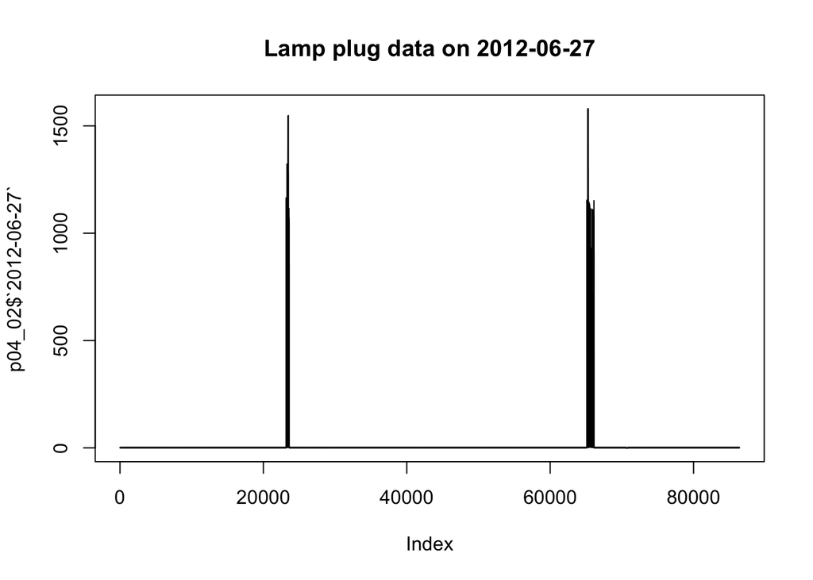

```r
# sample plot
plot(p04_02$`2012-06-27`, type = "l", main = "Lamp plug data on 2012-06-27")
```

There is clear difference in the pattern of different appliance.

Load 05 household to explore to see if there is any difference or similarity.

```r
## read data

## plug 05 household
# Measurement period:
# 27.06.12 to 31.01.13
#
# 01: Tablet (no. days: 218, coverage: 97.87%)
# 02: Coffee machine (no. days: 218, coverage: 95.16%)
# 03: Fountain (no. days: 71, coverage: 99.43%) (*)
# 04: Microwave (no. days: 218, coverage: 97.87%)
# 05: Fridge (no. days: 218, coverage: 97.87%)
# 06: Entertainment (no. days: 192, coverage: 89.14%) (**)
# 07: PC (no. days: 218, coverage: 97.87%) (***)
# 08: Kettle (no. days: 25, coverage: 76.64%)

appliance <- c("01", "02", "03", "04", "05", "06", "07", "08")
for (a in appliance) {
  file_list <-
    list.files(
      path = paste0("../../eco/05_plug/", a),
      pattern = ".csv",
      all.files = FALSE,
      full.names = FALSE
    )

  ## initiate variable name for each applicance
  df_name <- paste0("p05_", a)

  for (file in file_list) {
    path <- paste0("../../eco/05_plug/", a, "/", file)

    # if the merged dataset doesn't exist, create it
    if (!exists(df_name)) {
      temp <- read.table(path, header = FALSE)
      colnames(temp) <- substr(file, 1, 10)
      assign(df_name, temp)
      rm(temp)
      next
    }

    # if the merged dataset does exist, append to it
    if (exists(df_name)) {
      temp_dataset <- read.table(path, header = FALSE)
      colnames(temp_dataset) <- substr(file, 1, 10)
      temp <- cbind(get(df_name), temp_dataset)
      assign(df_name, temp)
      rm(temp_dataset, temp)
    }
  }
}
```

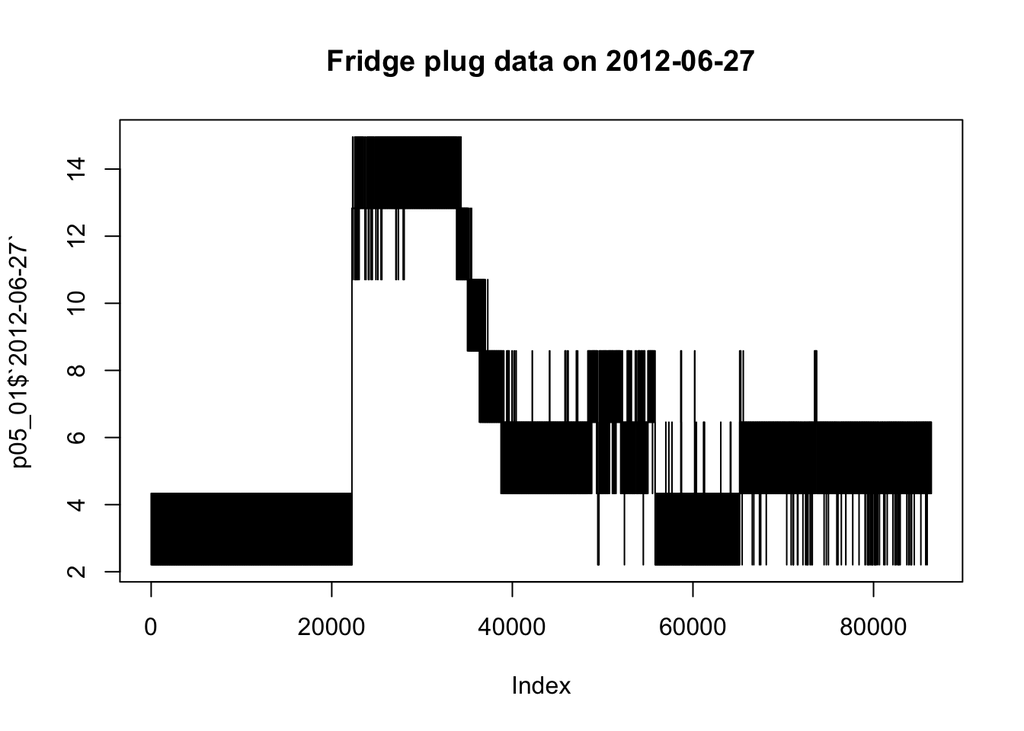

```r
# sample plot
plot(p05_01$`2012-06-27`, type = "l", main = "Fridge plug data on 2012-06-27")
```

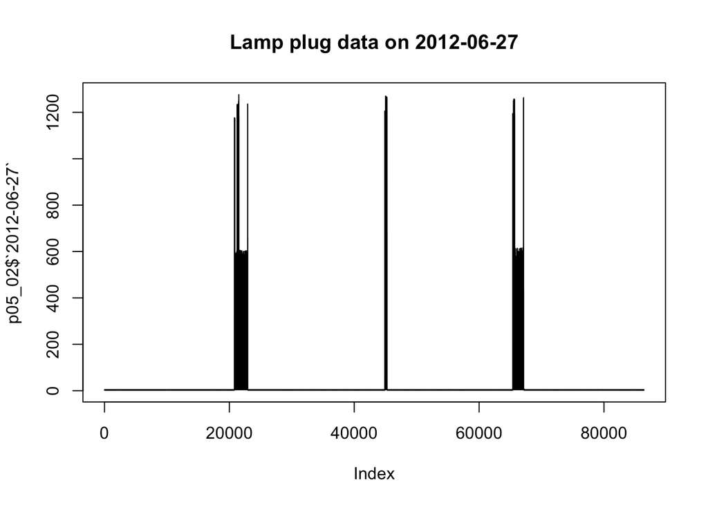

```r
# sample plot
plot(p05_02$`2012-06-27`, type = "l", main = "Lamp plug data on 2012-06-27")
```

##### Smart meter data

The concept of three-phase smart meter is explained [here](https://www.sms-plc.com/insights/what-does-the-3-phase-smart-meter-mean-for-the-smart-energy-revolution/). We are going to look at the total and each phase power.

```r
## read data

## plug 04 household
# SMART METER DATA
# ----------------
#
# Measurement period:
# 27.06.12 to 31.01.13
#
# Coverage:
# No. days: 219, Coverage: 99.39%


file_list <-
  list.files(
    path = paste0("../../eco/04_sm"),
    pattern = ".csv",
    all.files = FALSE,
    full.names = FALSE
  )



for (file in file_list) {
  path <- paste0("../../eco/04_sm/", file)

  for (phase in 0:3) {
    # if the merged dataset doesn't exist, create it

    ## initiate variable name for each phase
    df_phase <- paste0("s04_", phase)

    if (!exists(df_phase)) {
      temp <- read.csv(path, header = FALSE)
      temp <- data.frame(temp[, phase + 1])
      colnames(temp) <- substr(file, 1, 10)
      assign(df_phase, temp)
      rm(temp)
      next
    }

    # if the merged dataset does exist, append to it
    if (exists(df_phase)) {
      temp_dataset <- read.csv(path, header = FALSE)
      temp_dataset <- data.frame(temp_dataset[, phase + 1])
      colnames(temp_dataset) <- substr(file, 1, 10)
      temp <- cbind(get(df_phase), temp_dataset)
      assign(df_phase, temp)
      rm(temp_dataset, temp)
    }
  }
}
```

Reading the data cost several minutes. This indicate that the data need to be aggregate or processed in some way.

Plot 2012-06-27 for all phases.

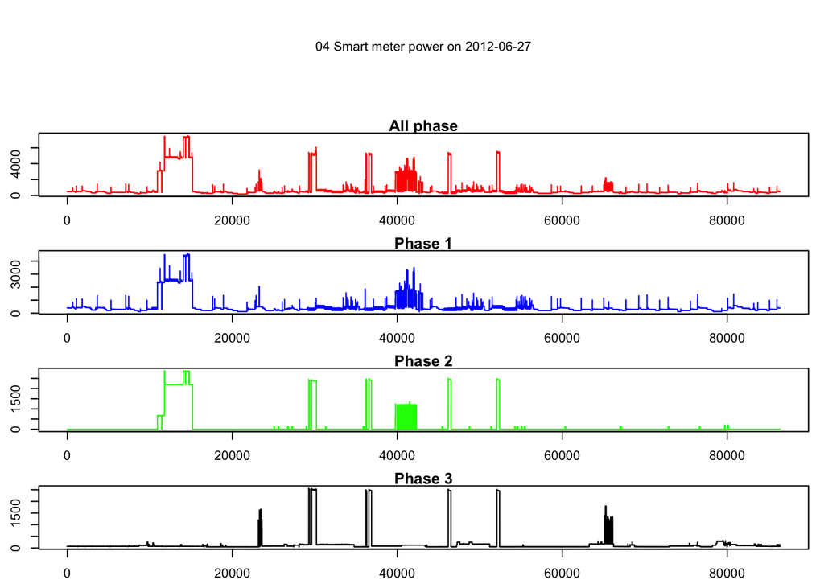

```r
par(mar=c(2.5,2.5,1,1))

layout(matrix(c(1,2,3,4,5),ncol=1),heights=c(2,2,2,2,2))

plot.new()
text(0.5,0.5,"04 Smart meter power on 2012-06-27")
plot(s04_0$`2012-06-27`, type = "l", main = "All phase", col ="red")
plot(s04_1$`2012-06-27`, type = "l", main = "Phase 1",col ="blue")
plot(s04_2$`2012-06-27`, type = "l", main = "Phase 2",col ="green")
plot(s04_3$`2012-06-27`, type = "l", main = "Phase 3",col ="black")
```

Compare for a different household.

```r
## read data

## plug 05 household

# SMART METER DATA
# ----------------
#
# Measurement period:
# 27.06.12 to 31.01.13
#
# Coverage:
# No. days: 215, Coverage: 99.05%


file_list <-
  list.files(
    path = paste0("../../eco/05_sm"),
    pattern = ".csv",
    all.files = FALSE,
    full.names = FALSE
  )



for (file in file_list) {
  path <- paste0("../../eco/05_sm/", file)

  for (phase in 0:3) {
    # if the merged dataset doesn't exist, create it

    ## initiate variable name for each phase
    df_phase <- paste0("s05_", phase)

    if (!exists(df_phase)) {
      temp <- read.csv(path, header = FALSE)
      temp <- data.frame(temp[, phase + 1])
      colnames(temp) <- substr(file, 1, 10)
      assign(df_phase, temp)
      rm(temp)
      next
    }

    # if the merged dataset does exist, append to it
    if (exists(df_phase)) {
      temp_dataset <- read.csv(path, header = FALSE)
      temp_dataset <- data.frame(temp_dataset[, phase + 1])
      colnames(temp_dataset) <- substr(file, 1, 10)
      temp <- cbind(get(df_phase), temp_dataset)
      assign(df_phase, temp)
      rm(temp_dataset, temp)
    }
  }
}
```

Plot 2012-06-27 for all phases for 05 household.

[figure not shown]

```r
par(mar=c(2.5,2.5,1,1))

layout(matrix(c(1,2,3,4,5),ncol=1),heights=c(2,2,2,2,2))

plot.new()
text(0.5,0.5,"04 Smart meter power on 2012-06-27")
plot(s05_0$`2012-06-27`, type = "l", main = "All phase", col ="red")
plot(s05_1$`2012-06-27`, type = "l", main = "Phase 1",col ="blue")
plot(s05_2$`2012-06-27`, type = "l", main = "Phase 2",col ="green")
plot(s05_3$`2012-06-27`, type = "l", main = "Phase 3",col ="black")
```

#### Data preparation

This session describes the data preparation for results analysis and visualization.

##### Plug data

The steps and code below describe the preparation of daily average consumption by household data.

1. Read data

```r
## read data

## plug 04 household
## Measurement period:
## 27.06.12 to 23.01.13

## 01: Fridge (no. days: 194, coverage: 97.01%)
## 02: Kitchen appliances (no. days: 194, coverage: 96.81%) (*)
## 03: Lamp (no. days: 170, coverage: 93.54%) (**)
## 04: Stereo and laptop (no. days: 169, coverage: 90.98%)
## 05: Freezer (no. days: 192, coverage: 93.08%)
## 06: Tablet (no. days: 189, coverage: 93.6%)
## 07: Entertainment (no. days: 186, coverage: 94.69%) (***)
## 08: Microwave (no. days: 194, coverage: 97.08%)

appliance <- c("01", "02", "03", "04", "05", "06", "07", "08")
for (a in appliance) {
  file_list <-
    list.files(
      path = paste0("../../eco/04_plug/", a),
      pattern = ".csv",
      all.files = FALSE,
      full.names = FALSE
    )

  ## initiate variable name for each applicance
  df_name <- paste0("p04_", a)

  for (file in file_list) {
    path <- paste0("../../eco/04_plug/", a, "/", file)

    # if the merged dataset doesn't exist, create it
    if (!exists(df_name)) {
      temp <- read.table(path, header = FALSE)
      colnames(temp) <- substr(file, 1, 10)
      assign(df_name, temp)
      rm(temp)
      next
    }

    # if the merged dataset does exist, append to it
    if (exists(df_name)) {
      temp_dataset <- read.table(path, header = FALSE)
      colnames(temp_dataset) <- substr(file, 1, 10)
      temp <- cbind(get(df_name), temp_dataset)
      assign(df_name, temp)
      rm(temp_dataset, temp)
    }
  }
}

## read data

## plug 05 household
# Measurement period:
# 27.06.12 to 31.01.13
#
# 01: Tablet (no. days: 218, coverage: 97.87%)
# 02: Coffee machine (no. days: 218, coverage: 95.16%)
# 03: Fountain (no. days: 71, coverage: 99.43%) (*)
# 04: Microwave (no. days: 218, coverage: 97.87%)
# 05: Fridge (no. days: 218, coverage: 97.87%)
# 06: Entertainment (no. days: 192, coverage: 89.14%) (**)
# 07: PC (no. days: 218, coverage: 97.87%) (***)
# 08: Kettle (no. days: 25, coverage: 76.64%)

appliance <- c("01", "02", "03", "04", "05", "06", "07", "08")
for (a in appliance) {
  file_list <-
    list.files(
      path = paste0("../../eco/05_plug/", a),
      pattern = ".csv",
      all.files = FALSE,
      full.names = FALSE
    )

  ## initiate variable name for each applicance
  df_name <- paste0("p05_", a)

  for (file in file_list) {
    path <- paste0("../../eco/05_plug/", a, "/", file)

    # if the merged dataset doesn't exist, create it
    if (!exists(df_name)) {
      temp <- read.table(path, header = FALSE)
      colnames(temp) <- substr(file, 1, 10)
      assign(df_name, temp)
      rm(temp)
      next
    }

    # if the merged dataset does exist, append to it
    if (exists(df_name)) {
      temp_dataset <- read.table(path, header = FALSE)
      colnames(temp_dataset) <- substr(file, 1, 10)
      temp <- cbind(get(df_name), temp_dataset)
      assign(df_name, temp)
      rm(temp_dataset, temp)
    }
  }
}

## read data

## plug 06 household
# PLUG DATA
# ---------
#
# Measurement period:
# 27.06.12 to 31.01.13
#
# 01: Lamp (no. days: 166, coverage: 67.2%)
# 02: Laptop (no. days: 185, coverage: 97.3%) (*)
# 03: Router (no. days: 88, coverage: 96.73%) (**)
# 04: Coffee machine (no. days: 179, coverage: 86.03%)
# 05: Entertainment (no. days: 181, coverage: 95.86%) (***)
# 06: Fridge (no. days: 179, coverage: 95.78%)
# 07: Kettle (no. days: 147, coverage: 82.54%)

appliance <- c("01", "02", "03", "04", "05", "06", "07")
for (a in appliance) {
  file_list <-
    list.files(
      path = paste0("../../eco/06_plug/", a),
      pattern = ".csv",
      all.files = FALSE,
      full.names = FALSE
    )

  ## initiate variable name for each applicance
  df_name <- paste0("p06_", a)

  for (file in file_list) {
    path <- paste0("../../eco/06_plug/", a, "/", file)

    # if the merged dataset doesn't exist, create it
    if (!exists(df_name)) {
      temp <- read.table(path, header = FALSE)
      colnames(temp) <- substr(file, 1, 10)
      assign(df_name, temp)
      rm(temp)
      next
    }

    # if the merged dataset does exist, append to it
    if (exists(df_name)) {
      temp_dataset <- read.table(path, header = FALSE)
      colnames(temp_dataset) <- substr(file, 1, 10)
      temp <- cbind(get(df_name), temp_dataset)
      assign(df_name, temp)
      rm(temp_dataset, temp)
    }
  }
}
```

2. Replace negative values (missing values) as NA

```r
households <- c("04", "05", "06")
appliance <- c("01", "02", "03", "04", "05", "06", "07", "08")

for (household in households) {
  for (a in appliance) {
    if (!(household == "06" && a == "08")) {
      df <- get(paste0("p", household, "_", a))
      df <- replace(df, df < 0, NA)
      assign(paste0("p", household, "_", a),df)
    }

  }
}
```

3. Compute daily average hourly consumption by each household and each appliance.

```r
daily_consum <- function(household) {

  # create empty df for res
  daily_power <- data.frame(matrix(ncol = 5, nrow = 0))

  #provide column names
  colnames(daily_power) <- c('household', 'daily_avg', 'appliance','hour','hour_avg')


  for (a in appliance) {
    if (household != "06") {
      df <- get(paste0("p", household, "_", a))

      ## compute hourly average through out all the days having data
      hour_avg <-
        rowMeans(aggregate(
          df,
          list(rep(
            1:(nrow(df) %/% 3600 + 1),
            each = 3600,
            len = nrow(df)
          )),
          sum,
          na.rm = TRUE,
          na.action = NULL
        )[-1]/ 3600000)



      curr_a_power <- data.frame(
        household = rep(household, 24),
        daily_avg = rep(NA, 24),
        appliance = rep(a, 24),
        hour = seq.int(24),
        hour_avg = hour_avg
      )
    }
    else {
      if (a != "08") {
        df <- get(paste0("p", household, "_", a))
        hour_avg <-
          rowMeans(aggregate(
            df,
            list(rep(
              1:(nrow(df) %/% 3600 + 1),
              each = 3600,
              len = nrow(df)
            )),
            sum,
            na.rm = TRUE,
            na.action = NULL
          )[-1]/ 3600000)


        curr_a_power <- data.frame(
          household = rep(household, 24),
          daily_avg = rep(NA, 24),
          appliance = rep(a, 24),
          hour = seq.int(24),
          hour_avg = hour_avg
        )

      }
      else {return(daily_power)}
    }

  daily_power <- rbind(daily_power, curr_a_power)

  }
  return(daily_power)
}

daily_power <-
  bind_rows(lapply(households, daily_consum), .id = "column_label")
```

4. Daily total by 8 appliances of each household

```r
daily_total_app <- daily_power %>% group_by(household) %>%
  summarise(sum_app=sum(hour_avg),
            .groups = 'drop')

daily_power$daily_avg <- daily_total_app$sum_app[match(unlist(daily_power$household), daily_total_app$household)]
```

4. Save the data

```r
write.csv(daily_power, "../data/daily_consum.csv", row.names=FALSE)
```

##### Smart meter data

1. Read data

```r
## read data

## 04 household
# SMART METER DATA
# ----------------
#
# Measurement period:
# 27.06.12 to 31.01.13
#
# Coverage:
# No. days: 219, Coverage: 99.39%


file_list <-
  list.files(
    path = paste0("../../eco/04_sm"),
    pattern = ".csv",
    all.files = FALSE,
    full.names = FALSE
  )



for (file in file_list) {
  path <- paste0("../../eco/04_sm/", file)

  for (phase in 0:3) {
    # if the merged dataset doesn't exist, create it

    ## initiate variable name for each phase
    df_phase <- paste0("s04_", phase)

    if (!exists(df_phase)) {
      temp <- read.csv(path, header = FALSE)
      temp <- data.frame(temp[, phase + 1])
      colnames(temp) <- substr(file, 1, 10)
      assign(df_phase, temp)
      rm(temp)
      next
    }

    # if the merged dataset does exist, append to it
    if (exists(df_phase)) {
      temp_dataset <- read.csv(path, header = FALSE)
      temp_dataset <- data.frame(temp_dataset[, phase + 1])
      colnames(temp_dataset) <- substr(file, 1, 10)
      temp <- cbind(get(df_phase), temp_dataset)
      assign(df_phase, temp)
      rm(temp_dataset, temp)
    }
  }
}

## 05 household

# SMART METER DATA
# ----------------
#
# Measurement period:
# 27.06.12 to 31.01.13
#
# Coverage:
# No. days: 215, Coverage: 99.05%


file_list <-
  list.files(
    path = paste0("../../eco/05_sm"),
    pattern = ".csv",
    all.files = FALSE,
    full.names = FALSE
  )



for (file in file_list) {
  path <- paste0("../../eco/05_sm/", file)

  for (phase in 0:3) {
    # if the merged dataset doesn't exist, create it

    ## initiate variable name for each phase
    df_phase <- paste0("s05_", phase)

    if (!exists(df_phase)) {
      temp <- read.csv(path, header = FALSE)
      temp <- data.frame(temp[, phase + 1])
      colnames(temp) <- substr(file, 1, 10)
      assign(df_phase, temp)
      rm(temp)
      next
    }

    # if the merged dataset does exist, append to it
    if (exists(df_phase)) {
      temp_dataset <- read.csv(path, header = FALSE)
      temp_dataset <- data.frame(temp_dataset[, phase + 1])
      colnames(temp_dataset) <- substr(file, 1, 10)
      temp <- cbind(get(df_phase), temp_dataset)
      assign(df_phase, temp)
      rm(temp_dataset, temp)
    }
  }
}

## 06 household

# SMART METER DATA
# ----------------
#
# Measurement period:
# 27.06.12 to 31.01.13
#
# Coverage:
# No. days: 166, Coverage: 99.67%


file_list <-
  list.files(
    path = paste0("../../eco/06_sm"),
    pattern = ".csv",
    all.files = FALSE,
    full.names = FALSE
  )



for (file in file_list) {
  path <- paste0("../../eco/06_sm/", file)

  for (phase in 0:3) {
    # if the merged dataset doesn't exist, create it

    ## initiate variable name for each phase
    df_phase <- paste0("s06_", phase)

    if (!exists(df_phase)) {
      temp <- read.csv(path, header = FALSE)
      temp <- data.frame(temp[, phase + 1])
      colnames(temp) <- substr(file, 1, 10)
      assign(df_phase, temp)
      rm(temp)
      next
    }

    # if the merged dataset does exist, append to it
    if (exists(df_phase)) {
      temp_dataset <- read.csv(path, header = FALSE)
      temp_dataset <- data.frame(temp_dataset[, phase + 1])
      colnames(temp_dataset) <- substr(file, 1, 10)
      temp <- cbind(get(df_phase), temp_dataset)
      assign(df_phase, temp)
      rm(temp_dataset, temp)
    }
  }
}
```

2. Replace negative values (missing values) as NA

```r
households <- c("04", "05", "06")

for (household in households) {
  for (phase in 0:3) {
    df <- get(paste0("s", household, "_", phase))
    df <- replace(df, df < 0, NA)
    assign(paste0("s", household, "_", phase),df)

  }
}
```

3. Compute 10min total consumption for each phase, kwh

```r
semihour_consum <- function(household) {
  # create empty df for res
  semihour <- data.frame(matrix(ncol = 3, nrow = 0))

  #provide column names
  colnames(semihour) <- c('household', 'phase', 'semihour_total')

  for (phase in 0:3) {

      df <- get(paste0("s", household, "_", phase))

      # daily_total <-
      #   colSums(df,
      #     na.rm = TRUE) / 3600000

      semihour_t <-
        rowMeans(aggregate(
          df,
          list(rep(
            1:(nrow(df) %/% 600 + 1),
            each = 600,
            len = nrow(df)
          )),
          sum,
          na.rm = TRUE,
          na.action = NULL
        )[-1]/ 3600000)

      curr_consum <- data.frame(
        household = rep(household, 144),
        phase = rep(phase, 144),
        semihour_total = semihour_t
      )
      semihour <- rbind(semihour, curr_consum)
  }

  return(semihour)
}

semi_comsum <-
  bind_rows(lapply(households, semihour_consum), .id = "column_label")
```

4. Save the data

```r
write.csv(semi_comsum, "../data/semihour_phase.csv", row.names=FALSE)
```

##### Plotly data

The code below describes preparation of the Plotly visualization data.

```r
## using smart meter data, the first 2 weeks of data

ten_min_day <- function(household) {

  # create empty df for res
  res <- data.frame(matrix(ncol = 5, nrow = 0))

  #provide column names
  colnames(res) <- c('household', 'phase', 'value','date','time')

  for (phase in 0:3) {

      df <- get(paste0("s", household, "_", phase))
      df <- df[,1:14]

      # daily_total <-
      #   colSums(df,
      #     na.rm = TRUE) / 3600000

      ten_d <- aggregate(
          df,
          list(rep(
            1:(nrow(df) %/% 600 + 1),
            each = 600,
            len = nrow(df)
          )),
          sum,
          na.rm = TRUE,
          na.action = NULL
        )[-1]/ 3600000
      ten_d$time <- format( seq.POSIXt(as.POSIXct(Sys.Date()), as.POSIXct(Sys.Date()+1), by = "10 min"),
          "%H:%M", tz="GMT")[1:144]

      ## convert ten_d to long format
      ten_d_long <- melt(setDT(ten_d), id.vars = "time", variable.name = "date")

      ten_d_long$household <- rep(household, 2016)
      ten_d_long$phase <- rep(phase, 2016)

      res <- rbind(ten_d_long,res)
  }


    return(res)
}

ten_min_day <-
  bind_rows(lapply(households, ten_min_day), .id = "column_label")
```

Save the data

```r
write.csv(ten_min_day[,2:6], "../data/ten_min_day.csv", row.names=FALSE)
```

### Results

The Plotly (Figure 1) is used to generate the visualization of the first 14 days 10-minutes energy usage by different households and different phases. The Plotly drop-down and slider features can be used to filter households and the date. The drop-down menu of Plotly is more flexible compared to the dropdown filter in Altair. There are three households. The number of drop-down menu options can be anything, but better with less options other than more. The slider, on the other hand, can handle more traces. Thus, I used drop-down menu to filter the households, while the slider is the filter of 14 dates. I aggregated the secondly data to 10-minutes, so that the pattern is more obvious. Moreover, I included a spike line and tooltip making the comparison among phases and the total on the same time point easier.

The Altair (Figure 2) is used to generate the visualization of the comparison of total and individual appliance usage by household through out the day. I choose to use the combination of barplot-pie chart-barplot to show the interaction of different household can have different appliance usage at various time. When use select a household or all of the households in the first bar plot, the pie chart will show the usage for that household/total usage by appliance. I also included a tooltip to show the daily total usage by those appliances. In this way, user can see how the appliance usage different from households. Moreover, I designed a second selection as the appliance. When user click the pie chart for particular appliance, the third chart, bar plot, shows the average hourly usage by selected appliance for that household. I have considered using a stacked barplot to combied the first two plots. However, I think either using the normalized bar plot or the standard stacked bar plot, there are some information lost. For example, using normalized bar plot lost the sense of the comparison among total usage of different households, while using standard stacked bar plot making the comparison among appliance usage across different households hard.

### Visualizations

#### Plotly with dropdown menu and slider

Dropdown menu as the households, and slider as the date (first 2 weeks of the data)

```python
import numpy as np
  import pandas as pd
  import altair as alt
  import datetime as dt
  import plotly.io as pio
  import plotly.express as px
  import plotly.offline as pyo
  import plotly.graph_objects as go
  from plotly.subplots import make_subplots

  %matplotlib inline

  pio.renderers.default = "plotly_mimetype+notebook_connected"
  # pyo.init_notebook_mode()
  # import plotly.io as pio
  #pio.renderers.default = 'iframe_connected'
```

```python
from IPython.core.interactiveshell import InteractiveShell
  InteractiveShell.ast_node_interactivity = "last"
```

```python
## import data (processed by R)

  ## ten-minus summary for each household each day smart meter data
  ten_min_day = pd.read_csv('../data/ten_min_day.csv')

  ## formatting for later use
  ten_min_day['datetime'] = ten_min_day["date"] +"-"+ ten_min_day["time"]
  ten_min_day['date']= pd.to_datetime(ten_min_day['date'])
  ten_min_day['datetime']= pd.to_datetime(ten_min_day['datetime'])
  #ten_min_day.info()
```

```python
## add a column as daily total consumption
  #daily_tol = ten_min_day.groupby(['date','household']).agg({'value': 'sum'})['value']
  #ten_min_day = pd.merge(ten_min_day, daily_tol,  how='left', left_on=['date','household'], right_on = ['date','household'])
  #ten_min_day = ten_min_day.rename(columns={"value_x": "ten_mins", "value_y": "daily_tol"})
  ten_min_day.head()
```

[output not shown]

```python
# INITIALIZE GRAPH OBJECT
  fig = go.Figure(layout=dict(
      legend=dict(groupclick="toggleitem")))

  # fig = make_subplots(rows=4, cols=1, vertical_spacing=0.065, shared_xaxes=True)

  # ADD TRACES: [c1*y1, c1*y2, c1*y3,..c2*y1, c2*y2,..]
  for house in pd.unique(ten_min_day.household):  # 3 household
      for s in pd.unique(ten_min_day.date):  # 14 days

          df1 = ten_min_day.loc[(ten_min_day['household'] == house) & (
              ten_min_day['date'] == s)]
          total_df = df1.loc[(df1['phase'] == 0)]
          p1_df = df1.loc[(df1['phase'] == 1)]
          p2_df = df1.loc[(df1['phase'] == 2)]
          p3_df = df1.loc[(df1['phase'] == 3)]

          fig.add_trace(
              go.Scatter(x=list(total_df.time), y=list(round(total_df.value,3)), visible=False, name="Total",
                         line=dict(color='red'),))
          fig.add_trace(
              go.Scatter(x=list(p1_df.time), y=list(round(p1_df.value,3)), visible=False, name="Phase 1",
                         line=dict(color='blue')))
          fig.add_trace(
              go.Scatter(x=list(p2_df.time), y=list(round(p2_df.value,3)), visible=False, name="Phase 2",
                         line=dict(color='green')))
          fig.add_trace(
              go.Scatter(x=list(p3_df.time), y=list(round(p3_df.value,3)), visible=False, name="Phase 3",
                         line=dict(color='orange')))

          # total 4*14*3 traces

          # fig.add_trace(
          #     go.Scatter(
          #     visible=False,
          #     line=dict(color="#00CED1", width=6),
          #     name="Date : " + str(step),
          #     x=pd.unique(ten_min_day.date),
          #     y=ten_min_day.value))

  # Create and add slider
  steps = []

  # for each year and each continent

  for i in range(3*14):
      label = [str(s) for s in ten_min_day['date'].dt.strftime(
          '%Y-%m-%d(%a)').unique()]
      step = dict(
          method="update",
          label=label[i % 14],
          args=[{"visible": [False]*3*14*4},
          {"title": "Daily total consumption: " + str("%.2f" % ten_min_day.groupby(['date','household']).agg({'value': 'sum'})['value'][i]) + " kW.h"}],
          # layout attribute
      )

      step["args"][0]["visible"][i*4] = True
      step["args"][0]["visible"][i*4+1] = True
      step["args"][0]["visible"][i*4+2] = True
      step["args"][0]["visible"][i*4+3] = True  # Toggle i'th trace to "visible"
      steps.append(step)

  sliders = []

  for i in np.arange(0, 3*14, 14):
      slider = [dict(
          active=0,
          currentvalue={"prefix": "Date: " },
          pad={"t": 50},
          steps=steps[i:i+14],


      )]
      sliders.append(slider)

  # INITIALIZE
  # MAKE FIRST TRACE VISABLE
  fig.data[0].visible = True
  fig.data[1].visible = True
  fig.data[2].visible = True
  fig.data[3].visible = True
  fig.update_layout(sliders=sliders[0])


  # ADD DROPDOWN TO CHANGE TYPE
  # "restyle": modify data or data attributes
  # "relayout": modify layout attributes
  # "update": modify data and layout attributes
  # "animate": start or pause an animation

  fig.update_layout(
      title=dict(text="Smart power 10-mins usage by household",
                 font=dict(size=25), yref='paper'),
      legend_title="Phase",
      xaxis_title="Time",
      yaxis_title="Energy consumption, kW.h",
      plot_bgcolor="floralwhite",
      showlegend=True,
      hovermode='x'

  )
  fig.update_xaxes(tickangle=-45,
                   showspikes=True,
                   spikemode='across',
                   spikesnap='cursor',
                   showline=True,
                   showgrid=True,
                   spikethickness=1,

                   )
  # IMPORTANT WITH MULTIPLE ARGS YOU NEED EACH IN A DICTIONARY FOR SOME REASON
  fig.update_layout(

      updatemenus=[
          dict(
              buttons=list([
                  dict(
                      label="Household 04",
                      method="update",
                      args=[{"visible": [False]*0*4+[True]*4+[False]
                             * (3*14-1)*4}, {"sliders": sliders[0]}],


                  ),
                  dict(
                      label="Household 05",
                      method="update",
                      args=[{"visible": [False]*14*4+[True]*4+[False]
                             * (3*14-1-14)*4}, {"sliders": sliders[1]}],
                  ),
                  dict(
                      label="Household 06",
                      method="update",
                      args=[{"visible": [False]*28*4+[True]*4+[False]
                             * (3*14-1-14*2)*4}, {"sliders": sliders[2]}],

                  )
              ]),
              direction="down",
              showactive=True,
              pad={"r": 10, "t": 10},
              x=0.89,
              xanchor="left",
              y=1.2,
              yanchor="auto",

          )
      ]
  )
  # import plotly as plt
  fig.show(renderer="notebook_connected")
  # # Plot it and save as basic-line.html
  # plt.offline.plot(fig, filename = 'Test-1.html', auto_open = False)

  # # Show HTML
  # from IPython.display import HTML
  # HTML(filename='Test-1.html')
```

[interactive chart not shown]

Figure 1: 10-minutes energy consumption for first 14 days

#### Altair

Energy consumption across households and appliances

```python
  ## import data
  ## average hourly summary from all existing date by household for each applicance

  hourly_app = pd.read_csv('../data/daily_consum.csv')
  #hourly_app.info()
```

```python
#hourly_app.head()
```

```python
alt.data_transformers.enable('default', max_rows=None)
```

```python
### first plot show the the average daily consumption

  selection_bar = alt.selection_single(fields=['household'],name='House')
  color_bar = alt.condition(selection_bar,
                        alt.value('sienna'),
                        alt.value('lightgray'))

  bar=(alt.Chart(hourly_app)
   .mark_bar(size=30)
   .encode(y='daily_avg:Q',
           x='household:N',
           color=color_bar
          )
  )

  text_bar = bar.mark_text(
      align='center',
      baseline='bottom',
      dx=1  # Nudges text to right so it doesn't appear on top of the bar
  ).encode(
      text=alt.Text("daily_avg:Q", format=",.2f")
  )


  bar.title =["Daily average energy consumption","by household"]
  bar.encoding.x.title = 'Households'
  bar.encoding.y.title = 'Daily consumption, kW.h'
  #(bar + text_bar).properties(width=200).add_selection(selection_bar)
```

```python
# pie chart to see the appliance use percentage

  selection_app = alt.selection_single(encodings=['theta','color'],name='app')
  selection_app1 = alt.selection_single(fields=['appliance_name'],name='app1')
  # color_app = alt.condition(selection_app,
  #                       'appliance_name',
  #                       alt.value('lightgray'))
  opacity_app = alt.condition(selection_app, alt.value(1.0), alt.value(0.2))

  base = alt.Chart(hourly_app).transform_filter(selection_bar
  ).encode(
      theta=alt.Theta("usage:Q", stack=True),
      color=alt.Color('appliance_name:N', legend=None),
      opacity=opacity_app,
      tooltip='combined_tooltip:N',
  ).transform_aggregate(
      usage = 'sum(hour_avg)',
      groupby=["appliance_name"]

  ).transform_calculate(
      round_usage = 'round(datum.usage*1000)/1000',
      combined_tooltip = "'Usage: ' + datum.round_usage + ' kW.h'"
      )

  pie = base.mark_arc(outerRadius=120)
  text_pie = base.mark_text(baseline="bottom",radius=120, size=12,lineBreak=" ",radiusOffset=22
              ).encode(text="appliance_name:N"
              )

  # pie plot title
  pie.title =["Usage by appliances"]

  #(bar + text_bar).properties(width=200,height=310).add_selection(selection_bar) | (pie + text_pie).properties(height=310).add_selection(selection_app).add_selection(selection_app1)
```

```python
## barplot show usage for every hour

  color_hour = alt.condition(selection_app,
                        alt.Color('appliance_name:N'),
  #                       alt.value('steelblue'),
                        alt.value('lightgray'))

  bar_hour=(alt.Chart(hourly_app)
   .mark_bar()
   .transform_filter(selection_bar
   ).transform_filter(selection_app1)
   ).encode(x=alt.X('hour:N'),
           y=alt.Y('hour_avg:Q'),
           color=alt.Color('appliance_name:N', legend=None)

          )


  bar_hour.title ="Appliance energy consumption"
  bar_hour.encoding.x.title = 'Hour'
  bar_hour.encoding.y.title = 'Energy consumption, kW.h'

  (bar + text_bar).properties(width=200,height=310).add_selection(selection_bar) | (pie + text_pie).properties(height=310).add_selection(selection_app).add_selection(selection_app1) | bar_hour.properties(height=310)
```

[interactive chart not shown]

Figure 2: Appliance usage distribution by households

## Reference

Beckel, Christian, Wilhelm Kleiminger, Romano Cicchetti, Thorsten Staake, and Silvia Santini. 2014. “The ECO Data Set and the Performance of Non-Intrusive Load Monitoring Algorithms.” *Proceedings of the 1st ACM International Conference on Embedded Systems for Energy-Efficient Buildings (BuildSys 2014)*.

Kleiminger, Wilhelm, Christian Beckel, and Silvia Santini. 2015. “Household Occupancy Monitoring Using Electricity Meters.” *Proceedings of the 2015 ACM International Joint Conference on Pervasive and Ubiquitous Computing (UbiComp 2015)*.